# Social Connection and Well-Being in the GSS, 1972–2024

Weighted descriptive analysis with SQL, survey weights and logistic regression

Zihe (Eric) Zhang

November 2026

# 1 Introduction

This project uses the General Social Survey (GSS) to examine friendship, emotions, sociability, social mobility and social trust among U.S. adults. It asks two questions:

1. How have responses changed across survey years?
2. How do responses differ across age groups?

This version extends my earlier unweighted analysis in four ways: (1) the summaries are built in **SQL**, (2) estimates use the **GSS survey weights** with 95% confidence intervals, (3) the 2021–2024 **change in interview mode** is checked, and (4) simple **logistic regressions** separate age differences from period differences.

The analysis is descriptive: it shows patterns, not causes.

# 2 Data

- **Source:** GSS 1972–2024 cumulative file (NORC at the University of Chicago), read either from the official Stata file or from the `gssr` R package (`R/01_prepare_data.R`).
- **Sample:** 75,699 respondents across 35 survey years.
- **Weights:** `WTSSPS` (post-stratification weight recommended by NORC for the cumulative file), with `VPSU` and `VSTRAT` describing the clustered sample design.

## 2.1 Variables

| Theme | Variable | Question | Scale | Indicator used |
| --- | --- | --- | --- | --- |
| Feelings | HAPPY | General happiness | 1 = very happy … 3 = not too happy | % very happy |
| Friendship | SOCFREND | Social evenings with friends | 1 = almost daily … 7 = never | % at least weekly (codes 1–2) |
| Sociability | SOCBAR | Going to a bar or tavern | 1 = almost daily … 7 = never | mean code |
| Social mobility | PARSOL | Living standard vs. parents at same age | 1 = much better … 5 = much worse | % better (codes 1–2) |
| Trust | TRUST | Can most people be trusted? | 1 = can trust, 2 = can’t be too careful, 3 = depends | % can trust |

Because the items are **ordinal**, the main results use percentages of clearly defined categories and full response distributions rather than means of the codes.

## 2.2 Check: the data reproduce my original numbers

```sql
SELECT year,
       ROUND(100.0 * AVG(very_happy), 1)     AS pct_very_happy,
       ROUND(100.0 * AVG(people_trusted), 1) AS pct_trust
FROM gss
WHERE year IN (1972, 2024)
GROUP BY year
```

2 records

| year | pct_very_happy | pct_trust |
| --- | --- | --- |
| 1972 | 30.3 | 46.2 |
| 2024 | 20.8 | 24.9 |

These unweighted values (30.3% → 20.8% very happy; 46.2% → 24.9% trust) match my original report.

# 3 SQL summaries

All unweighted summaries are produced by `sql/queries.sql`. Two examples:

**Year coverage.** Not every question was asked every year. `AVG()` ignores `NULL`, so years without a question show as missing, not zero.

```sql
SELECT year,
       COUNT(happy)    AS happy_n,
       COUNT(trust)    AS trust_n,
       COUNT(socfrend) AS socfrend_n,
       COUNT(parsol)   AS parsol_n
FROM gss
GROUP BY year
ORDER BY year DESC
```

Displaying records 1 - 12

| year | happy_n | trust_n | socfrend_n | parsol_n |
| --- | --- | --- | --- | --- |
| 2024 | 3281 | 946 | 2166 | 2159 |
| 2022 | 3520 | 1198 | 2366 | 2329 |
| 2021 | 4014 | 0 | 2701 | 2653 |
| 2018 | 2344 | 1556 | 1557 | 1536 |
| 2016 | 2859 | 1946 | 1886 | 1932 |
| 2014 | 2530 | 1683 | 1675 | 1663 |
| 2012 | 1964 | 1331 | 1299 | 1308 |
| 2010 | 2039 | 1372 | 1425 | 1361 |
| 2008 | 2015 | 1365 | 1325 | 1339 |
| 2006 | 2986 | 2509 | 1989 | 1964 |
| 2004 | 1337 | 875 | 904 | 866 |
| 2002 | 1369 | 910 | 906 | 899 |

**Change between periods** using a CTE and the `LAG()` window function:

```sql
WITH by_period AS (
  SELECT period, MIN(year) AS first_year,
         ROUND(100.0 * AVG(very_happy), 1)     AS pct_very_happy,
         ROUND(100.0 * AVG(people_trusted), 1) AS pct_trust
  FROM gss GROUP BY period
)
SELECT period, pct_very_happy,
       ROUND(pct_very_happy - LAG(pct_very_happy) OVER (ORDER BY first_year), 1) AS change_happy,
       pct_trust,
       ROUND(pct_trust - LAG(pct_trust) OVER (ORDER BY first_year), 1)           AS change_trust
FROM by_period ORDER BY first_year
```

6 records

| period | pct_very_happy | change_happy | pct_trust | change_trust |
| --- | --- | --- | --- | --- |
| 1970s | 34.3 | NA | 43.1 | NA |
| 1980s | 31.8 | -2.5 | 41.2 | -1.9 |
| 1990s | 30.9 | -0.9 | 36.0 | -5.2 |
| 2000s | 30.8 | -0.1 | 33.8 | -2.2 |
| 2010-2018 | 29.2 | -1.6 | 32.0 | -1.8 |
| 2021-2024 | 20.8 | -8.4 | 25.1 | -6.9 |

# 4 Weighted estimates

The weighted estimates come from the `survey` package:

```r
des <- svydesign(ids = ~vpsu, strata = ~vstrat, weights = ~wtssps,
                 nest = TRUE, data = gss)
svyby(~very_happy, ~year, subset(des, !is.na(very_happy)), svymean, na.rm = TRUE)
```

## 4.1 Happiness over time

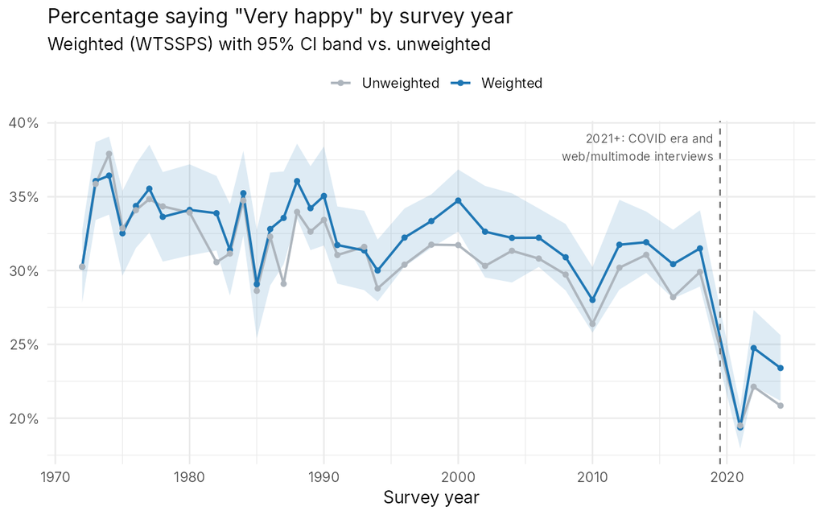

- From 1972 to 2018, the weighted share saying “very happy” moved within roughly a 28–37% band: 30.3% in 1972 and 31.5% in 2018.
- It then dropped to 19.4% in 2021 and was 23.4% in 2024. **Most of the long-run decline happens at the 2021 break**, which coincides with both the COVID-19 pandemic and the switch to web/multimode interviewing.
- Weighting matters more in recent years: in 2024 the weighted estimate is 23.4% versus 20.8% unweighted.

## 4.2 Social trust over time

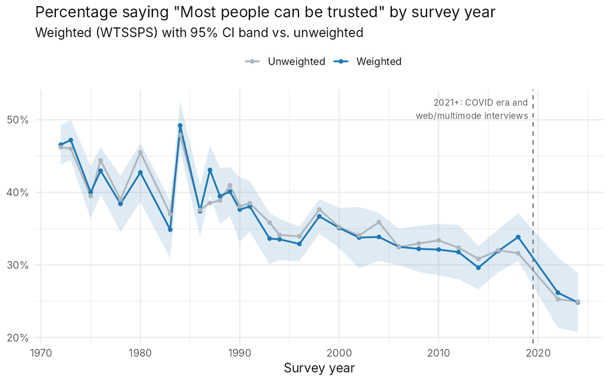

- Trust declined steadily **before** the mode change: from 46.6% in 1972 to 33.8% in 2018, and was 24.8% in 2024.
- TRUST was not asked in 2021, and in 2022 and 2024 it was asked almost entirely in person or by phone (only 65 web answers), so the recent low values are not a web-mode artifact.

```sql
SELECT year, mode_label, COUNT(trust) AS trust_answers, COUNT(happy) AS happy_answers
FROM gss
WHERE year >= 2021
GROUP BY year, mode_label
ORDER BY year, mode_label
```

8 records

| year | mode_label | trust_answers | happy_answers |
| --- | --- | --- | --- |
| 2021 | Phone | 0 | 291 |
| 2021 | Web/multimode | 0 | 3723 |
| 2022 | In person | 1036 | 1548 |
| 2022 | Phone | 132 | 200 |
| 2022 | Web/multimode | 30 | 1772 |
| 2024 | In person | 755 | 1162 |
| 2024 | Phone | 156 | 252 |
| 2024 | Web/multimode | 35 | 1867 |

## 4.3 Differences by age group

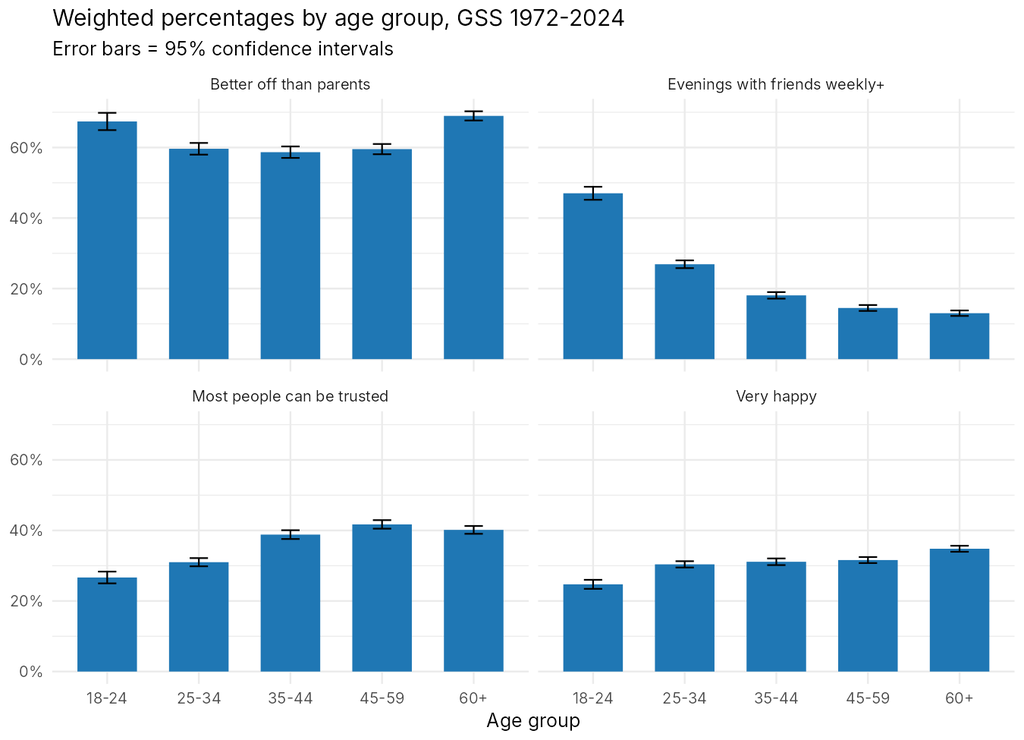

```r
age_tbl |>
  mutate(estimate = sprintf("%.1f%% (%.1f–%.1f)", pct, ci_low, ci_high)) |>
  select(indicator, age_group, estimate) |>
  tidyr::pivot_wider(names_from = age_group, values_from = estimate) |>
  kable(caption = "Weighted percentages by age group, with 95% CIs")
```

Weighted percentages by age group, with 95% CIs

| indicator | 18-24 | 25-34 | 35-44 | 45-59 | 60+ |
| --- | --- | --- | --- | --- | --- |
| Very happy | 24.7% (23.4–26.0) | 30.4% (29.5–31.3) | 31.1% (30.2–32.1) | 31.6% (30.8–32.5) | 34.8% (34.0–35.7) |
| Most people can be trusted | 26.7% (25.0–28.3) | 31.0% (29.8–32.2) | 38.8% (37.6–40.1) | 41.7% (40.5–42.9) | 40.2% (39.0–41.3) |
| Evenings with friends weekly+ | 47.0% (45.2–48.9) | 26.9% (25.8–28.0) | 18.1% (17.2–19.0) | 14.5% (13.7–15.3) | 13.0% (12.3–13.8) |
| Better off than parents | 67.4% (64.9–69.8) | 59.6% (58.0–61.3) | 58.7% (57.1–60.3) | 59.5% (58.1–61.0) | 69.0% (67.7–70.3) |

- **Friendship:** 47% of 18–24-year-olds spend an evening with friends at least weekly, compared with 13% of those 60+.
- **Happiness and trust are higher among older adults:** “very happy” goes from 24.7% (18–24) to 34.8% (60+); trust peaks at 41.7% among 45–59-year-olds.
- **Mobility is U-shaped:** 67.4% of 18–24 and 69% of 60+ say they are better off than their parents, versus 58.7% of 35–44.

### 4.3.1 Full response distribution (ordinal data)

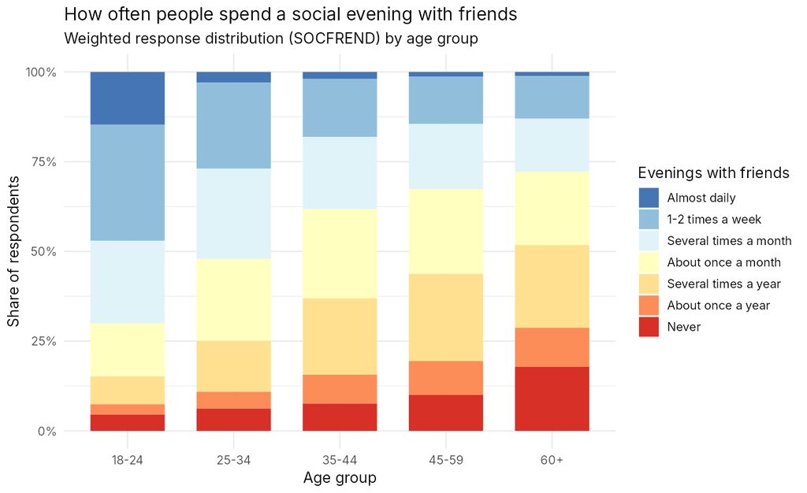

The stacked bars show the whole SOCFREND scale rather than one mean: the share answering “never” grows steadily with age, while “almost daily” is common only among 18–24-year-olds.

### 4.3.2 Happiness trends within each age group

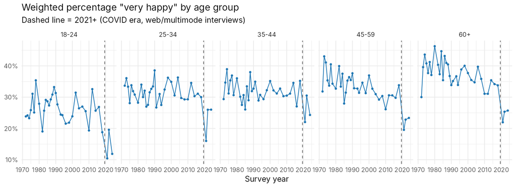

The 2021 drop appears in **every** age group, which fits a period-wide change (pandemic and/or survey mode) better than a change affecting one generation.

# 5 Survey-mode check (2022 and 2024)

In 2022 and 2024, respondents were interviewed in person, by phone or on the web.

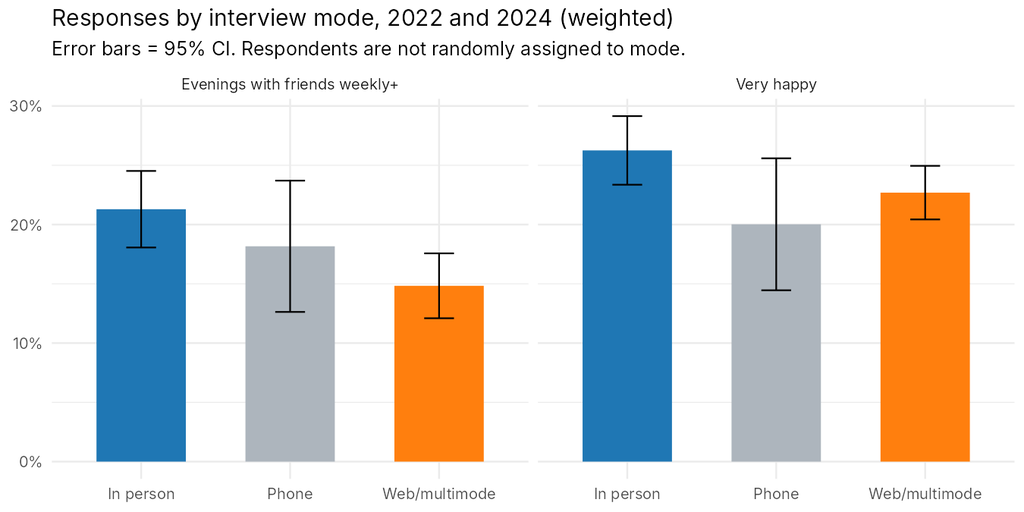

```r
or_all |>
  filter(outcome == "Very happy (2022-2024, mode model)", grepl("mode", term)) |>
  transmute(term, odds_ratio = round(odds_ratio, 2),
            ci = sprintf("%.2f–%.2f", or_low, or_high), p_value = signif(p_value, 2)) |>
  kable(caption = "Very happy ~ mode + age group + year (reference: in person)")
```

Very happy ~ mode + age group + year (reference: in person)

| term | odds_ratio | ci | p_value |
| --- | --- | --- | --- |
| mode_labelPhone | 0.63 | 0.42–0.94 | 0.025 |
| mode_labelWeb/multimode | 0.80 | 0.65–0.97 | 0.026 |

- Web/multimode respondents were less likely to say “very happy” (22.7% vs. 26.3% in person). After adjusting for age group and year, the odds ratio for web is 0.8.
- Respondents choose their mode, so this is **not** a clean experiment, but it suggests that part of the post-2021 drop in happiness may reflect *how* the question was asked.

# 6 Logistic regression: age vs. period

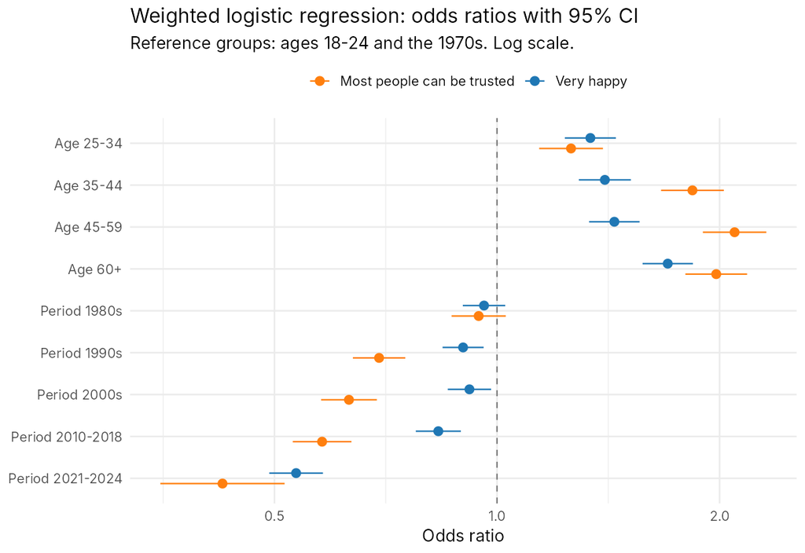

```r
svyglm(very_happy ~ age_group + period, design = des, family = quasibinomial())
svyglm(people_trusted ~ age_group + period, design = des, family = quasibinomial())
```

```r
or_all |>
  filter(outcome %in% c("Very happy", "Most people can be trusted"), term != "(Intercept)") |>
  transmute(outcome, term, odds_ratio = round(odds_ratio, 2),
            ci = sprintf("%.2f–%.2f", or_low, or_high), p_value = signif(p_value, 2)) |>
  kable(caption = "Odds ratios (reference: ages 18–24, 1970s)")
```

Odds ratios (reference: ages 18–24, 1970s)

| outcome | term | odds_ratio | ci | p_value |
| --- | --- | --- | --- | --- |
| Very happy | age_group25-34 | 1.34 | 1.24–1.45 | 0.0e+00 |
| Very happy | age_group35-44 | 1.40 | 1.29–1.52 | 0.0e+00 |
| Very happy | age_group45-59 | 1.44 | 1.33–1.56 | 0.0e+00 |
| Very happy | age_group60+ | 1.70 | 1.57–1.84 | 0.0e+00 |
| Very happy | period1980s | 0.96 | 0.90–1.03 | 2.3e-01 |
| Very happy | period1990s | 0.90 | 0.84–0.96 | 1.2e-03 |
| Very happy | period2000s | 0.92 | 0.86–0.98 | 1.3e-02 |
| Very happy | period2010-2018 | 0.83 | 0.78–0.89 | 3.0e-07 |
| Very happy | period2021-2024 | 0.53 | 0.49–0.58 | 0.0e+00 |
| Most people can be trusted | age_group25-34 | 1.26 | 1.14–1.39 | 5.5e-06 |
| Most people can be trusted | age_group35-44 | 1.84 | 1.67–2.03 | 0.0e+00 |
| Most people can be trusted | age_group45-59 | 2.10 | 1.90–2.31 | 0.0e+00 |
| Most people can be trusted | age_group60+ | 1.98 | 1.80–2.18 | 0.0e+00 |
| Most people can be trusted | period1980s | 0.94 | 0.87–1.03 | 1.8e-01 |
| Most people can be trusted | period1990s | 0.69 | 0.64–0.75 | 0.0e+00 |
| Most people can be trusted | period2000s | 0.63 | 0.58–0.69 | 0.0e+00 |
| Most people can be trusted | period2010-2018 | 0.58 | 0.53–0.64 | 0.0e+00 |
| Most people can be trusted | period2021-2024 | 0.43 | 0.35–0.52 | 0.0e+00 |

How to read this: an odds ratio above 1 means higher odds than the reference group, holding the other variable constant.

- **Age:** compared with 18–24-year-olds in the same period, people 60+ have 1.7 times the odds of being very happy and 45–59-year-olds have 2.1 times the odds of saying most people can be trusted.
- **Period, happiness:** odds stay within about 10% of the 1970s level through the 2000s (OR = 0.9–0.96), dip modestly in 2010–2018 (OR = 0.83), then fall sharply in 2021–2024 (OR = 0.53).
- **Period, trust:** the decline starts earlier. The odds are already lower in the 1990s (OR = 0.69) and keep falling to 0.43 in 2021–2024.

# 7 Main findings

1. **Happiness was fairly stable for 45 years, then dropped in 2021.** The weighted share “very happy” was 30.3% in 1972 and 31.5% in 2018, then 23.4% in 2024. The break coincides with COVID-19 and a change in survey mode, and web respondents report lower happiness.
2. **Trust has been declining for decades**, from 46.6% to 24.8%, and the recent values come mostly from in-person interviews.
3. **Younger adults socialize with friends much more often but are less happy and less trusting** than older adults, and these age gaps remain after controlling for survey period.
4. **Most adults in every age group feel better off than their parents**, with a U-shaped pattern across age groups.

# 8 Limitations

- **Age, period and cohort are mixed together.** Repeated cross-sections cannot fully separate getting older from being born in a different generation.
- **Mode and pandemic effects overlap** in 2021–2024 and cannot be fully separated.
- **Items are not asked every year** (e.g., TRUST not in 2021, PARSOL only from 1994).
- Ordinal answers were simplified into yes/no indicators for the regressions.

# 9 Next steps

- Add birth cohort to the models to explore age–period–cohort patterns.
- Use ordinal (proportional-odds) regression to keep the full response scales.
- Compare with other national surveys that did not change mode in 2021.

# 10 Source

Davern, M., Bautista, R., Freese, J., Herd, P., & Morgan, S. L. General Social Survey 1972–2024 [Data set]. NORC at the University of Chicago. Accessed via the `gssr` R package (Healy, K.).